# R Notebook

# Tableau and Leaflet-A Comparison in Geospatial Data Interactive Visualization

## Introduction

Tableau and R are usefull to visualize geospatial data. R provides several packages/functions to visulize geospatial data:

- ggplot2
- tmap
- plotly
- tmap
- leaflet + Shiny

## Leaflet

Usually when I try build interative geospatial visulization, I will combine both Shiny and leaflet.

> What is Leaflet?

Leaflet is a R package that allows you to build interative map without strong knowledge in javascript and CSS.

The best way to present geospatial data is using both shiny and leaflet. Here is the project I did using leaflet and shiny: https://mingzhong.shinyapps.io/hospital_intelligence/

[figure not shown]

Shiny App Example

Pretty cool, right? Let’s start with several simple examples and get the gist of leaflet.

> Installation

```r
install.packages("leaflet")
# to install the development version from Github, run
# devtools::install_github("rstudio/leaflet")
```

> Basic Example

```r
library(leaflet)
m <- leaflet() %>%
  addTiles() %>%  # Add default OpenStreetMap map tiles
  addMarkers(lng=174.768, lat=-36.852, popup="The birthplace of R")
m  # Print the map
```

[interactive chart not shown]

You create a Leaflet map with these basic steps:

1.Create a map widget by calling leaflet().

2.Add layers (i.e., features) to the map by using layer functions (e.g. addTiles, addMarkers, addPolygons) to modify the map widget.

3.Repeat step 2 as desired.

4.Print the map widget to display it.

> Read in Geospatial Data

Here is an example receiving spatial data from library(maps)

```r
library(maps)
mapStates = map("state", fill = TRUE, plot = FALSE)
leaflet(data = mapStates) %>% addTiles() %>%
  addPolygons(fillColor = topo.colors(10, alpha = NULL), stroke = FALSE)
```

[output not shown]

> Change Maps

You can even select the customized map style. There are different kinds of style because of the open source characteristic of Leaflet.

```r
m <- leaflet() %>% setView(lng = -71.0589, lat = 42.3601, zoom = 12)
m %>% addProviderTiles(providers$Stamen.Toner)
```

[interactive chart not shown]

> Shiny Integration

Finally, we want to inegrate Shiny with Leaflet. By building UI and SERVER, we can actually put leaflet map inside the R shiny app.

```r
library(shiny)
library(leaflet)

r_colors <- rgb(t(col2rgb(colors()) / 255))
names(r_colors) <- colors()

ui <- fluidPage(
  leafletOutput("mymap"),
  p(),
  actionButton("recalc", "New points")
)

server <- function(input, output, session) {

  points <- eventReactive(input$recalc, {
    cbind(rnorm(40) * 2 + 13, rnorm(40) + 48)
  }, ignoreNULL = FALSE)

  output$mymap <- renderLeaflet({
    leaflet() %>%
      addProviderTiles(providers$Stamen.TonerLite,
        options = providerTileOptions(noWrap = TRUE)
      ) %>%
      addMarkers(data = points())
  })
}

shinyApp(ui, server)
```

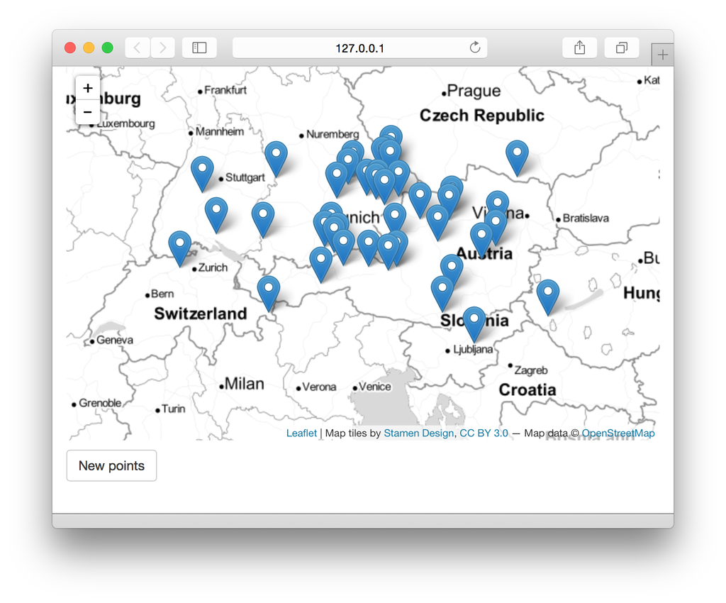

Shiny App Screenshot

We can even go further and add in some button to interact with map. Besides, we can even combine other kinds of graphs to make our data presentation even better !

[figure not shown]

Shiny App Screenshot

# Tableau

## Tableau

All in all, leaflet and Tableau are both great tool to visualize geospatial. We would like to choose different tools based on the condition. For simplicity and convenience, Tableau is for sure the best visualization tool. You can easily visualize data without any code. Anyone can learn Tableau within a short time.

## Leaflet

Although Tableau is easy to use and learn, leaflet is more preferable when we need to costomize your data presentation. Because of Shiny, we are able to combine Leaflet with other functions in R. if we would like to build a demo data visulization app using R, leaflet will be our top choice.

## Summary

Both Tableau and Leaflet+Shiny can be shared using a link. That helps a lot when you try to share your work.

References

https://rstudio.github.io/leaflet/shiny.html